# Assignment 2 ST302

Colm Mooney

2023-03-10

```r
#install.packages(c("vcd", "vcdExtra", "ggmosaic", "effects"))
library(vcd)
library(ggmosaic)
library(tidyverse)
library(vcdExtra)
library(effects)
```

## Question 1. (DONE)

```r
d <- data.frame(as.table(MSPatients))
glimpse(d)
```

```
## Rows: 32
## Columns: 4
## $ New.Orleans.Neurologist <fct> Certain, Probable, Possible, Doubtful, Certain…
## $ Winnipeg.Neurologist    <fct> Certain, Certain, Certain, Certain, Probable, …
## $ Patients                <fct> Winnipeg, Winnipeg, Winnipeg, Winnipeg, Winnip…
## $ Freq                    <dbl> 38, 33, 10, 3, 5, 11, 14, 7, 0, 3, 5, 3, 1, 0,…
```

1. Based on the information below, how do the distributions of the ratings of the neurologists compare? How would you describe their rating patterns? What geom is used here?

Very High Frequency of Certainty for Winnipeg. Least 95%. A little over 50% Frequency for Certainty for New Orleans.

There is an equal amount of Frequency for Probable in New Orleans and Winnipeg. The lowest recorded Frequency is for Possible. Slightly lower than 25% for Winnipeg.

The Frequency recorded for Possible in New Orleans is about 55%.

Doubtful has the lowest recorded frequency for New Orleans at about 43%. Doubtful has a frequency of about 35% for Winnipeg.

New Orleans Neurologist’s distribution is more consistent with the data compared to Winnipeg, as in the 4 possibilities roughly have the same values. However, Winnipeg’s seems to be the better Neurologist as he has a 95% Certainty Frequency.

The geom being used here is geom_col()

2. Here are two plots and a summarised dataset that compare the ratings of the two neurologists for the patients. What geoms are used in these plots? Comment on the agreement between the two raters.

geom_col & geom_mosaic are being used in these plots.

These plots are awful. Genuinely extremely confusing to read. i much prefer it being side to side like in Question A. I understand that it works that the Certain of W.N is being compared to the o4 in N.O.N and the same for Probable, Possible & Doubtful. The second graph is better than he third though.

## Question 2 (Done)

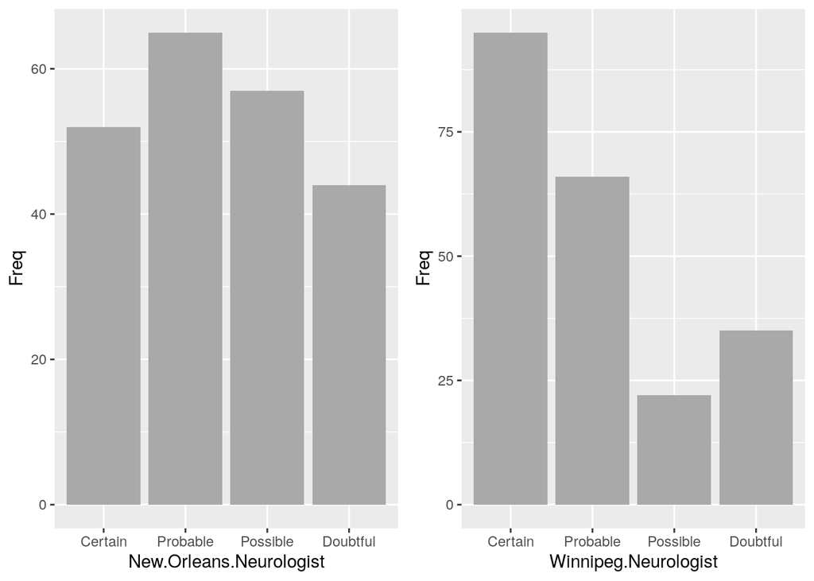

```r
require(gridExtra)
plot1 <- ggplot(d , aes(x = New.Orleans.Neurologist, y = Freq)) + geom_col(fill = "darkgray")
plot2 <- ggplot(d , aes(x = Winnipeg.Neurologist, y = Freq)) + geom_col(fill = "darkgray")
grid.arrange(plot1, plot2, ncol=2)
```

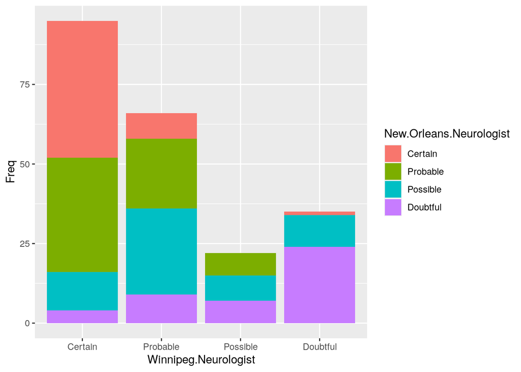

```r
#This is a the second plot
ggplot(d, aes(x= Winnipeg.Neurologist, y = Freq, fill = New.Orleans.Neurologist))+geom_col()
```

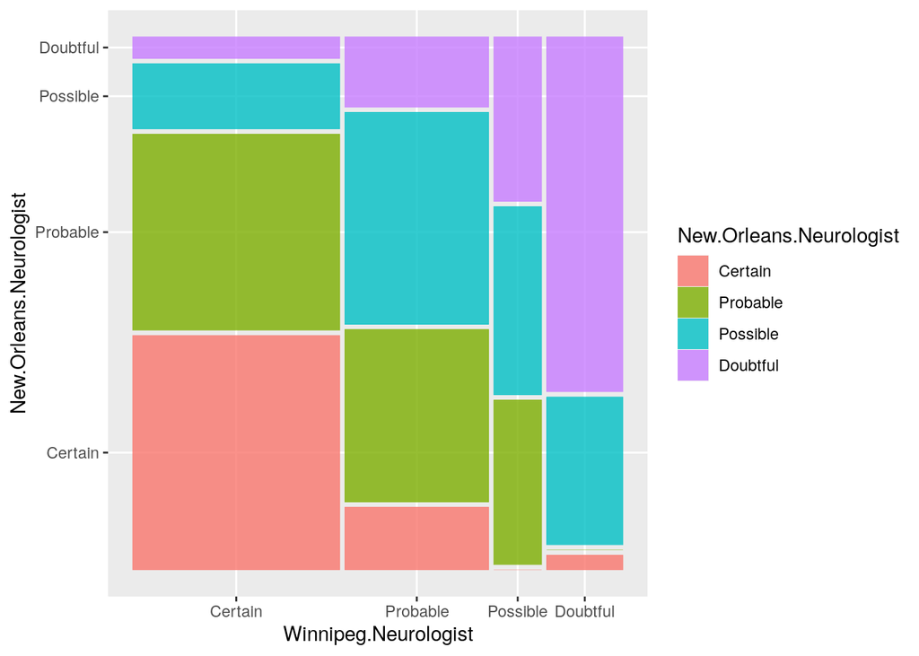

```r
#This is the third plot:
ggplot(d) + geom_mosaic(aes(weight = Freq, x = product(Winnipeg.Neurologist), fill = New.Orleans.Neurologist))
```

### The Table (Done)

```r
d %>% group_by(Winnipeg.Neurologist, New.Orleans.Neurologist) %>% tally(Freq) %>% mutate(prop = n / sum(n))
```

```
## # A tibble: 16 × 4
## # Groups:   Winnipeg.Neurologist [4]
##    Winnipeg.Neurologist New.Orleans.Neurologist     n   prop
##    <fct>                <fct>                   <dbl>  <dbl>
##  1 Certain              Certain                    43 0.453
##  2 Certain              Probable                   36 0.379
##  3 Certain              Possible                   12 0.126
##  4 Certain              Doubtful                    4 0.0421
##  5 Probable             Certain                     8 0.121
##  6 Probable             Probable                   22 0.333
##  7 Probable             Possible                   27 0.409
##  8 Probable             Doubtful                    9 0.136
##  9 Possible             Certain                     0 0
## 10 Possible             Probable                    7 0.318
## 11 Possible             Possible                    8 0.364
## 12 Possible             Doubtful                    7 0.318
## 13 Doubtful             Certain                     1 0.0286
## 14 Doubtful             Probable                    0 0
## 15 Doubtful             Possible                   10 0.286
## 16 Doubtful             Doubtful                   24 0.686
```

## Question 3

```r
glimpse(TitanicSurvival)
```

```
## Rows: 1,309
## Columns: 4
## $ survived       <fct> yes, yes, no, no, no, yes, yes, no, yes, no, no, yes, y…
## $ sex            <fct> female, male, female, male, female, male, female, male,…
## $ age            <dbl> 29.0000, 0.9167, 2.0000, 30.0000, 25.0000, 48.0000, 63.…
## $ passengerClass <fct> 1st, 1st, 1st, 1st, 1st, 1st, 1st, 1st, 1st, 1st, 1st, …
```

1. Calculate the dataset Age as in the code below. What does unite do? (DONE)

```r
TitanicSurvival |> group_by(survived,passengerClass,sex) |>
  summarize(age=mean(age, na.rm=T)) |>
  unite(survived, passengerClass, sex, col="group", remove = FALSE) -> age

TitanicSurvival %>% group_by(age)
```

```
## # A tibble: 1,309 × 4
## # Groups:   age [99]
##    survived sex       age passengerClass
##    <fct>    <fct>   <dbl> <fct>
##  1 yes      female 29     1st
##  2 yes      male    0.917 1st
##  3 no       female  2     1st
##  4 no       male   30     1st
##  5 no       female 25     1st
##  6 yes      male   48     1st
##  7 yes      female 63     1st
##  8 no       male   39     1st
##  9 yes      female 53     1st
## 10 no       male   71     1st
## # … with 1,299 more rows
```

```r
#Unite() allows you to combine multiple data columns into a single data column from a data frame.
```

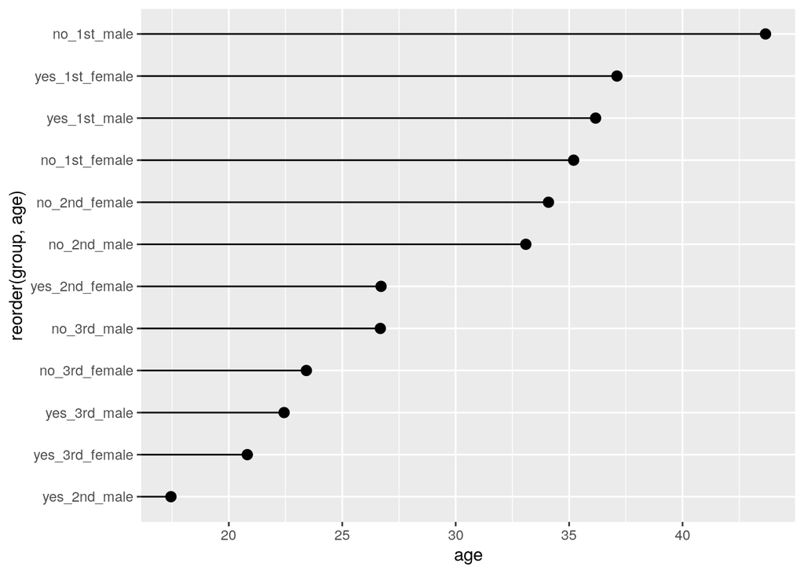

```r
#Part 1
ggplot(age, aes(x = age, y = reorder(group, age)))+geom_pointrange(xmin = 0, aes(xmax = age))
```

```r
#Part 2
ColorPlot <- age %>% unite(passengerClass, sex, col = "class.sex", sep = "-")

#ggplot(data = ColorPlot, aes(x = age, y = reorder(group, age), color = class.sex))+ geom_pointrange(xmin = 0, aes(xmas = age))
```

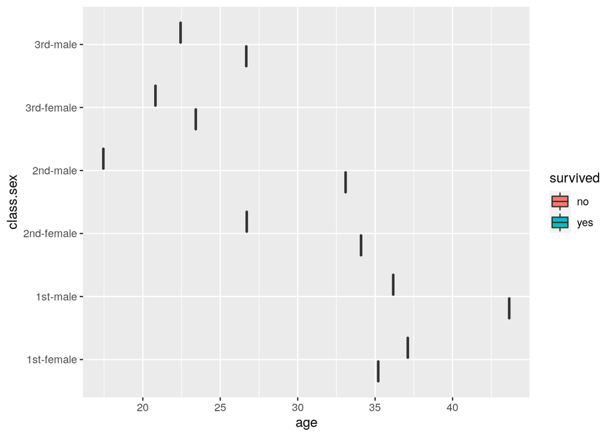

```r
ggplot(ColorPlot, aes(x=age, y = class.sex, fill= survived))+ geom_boxplot()
```

## Question 4 (Done)

```r
check <- data.frame(source("http://www.openintro.org/stat/data/cdc.R"))
```

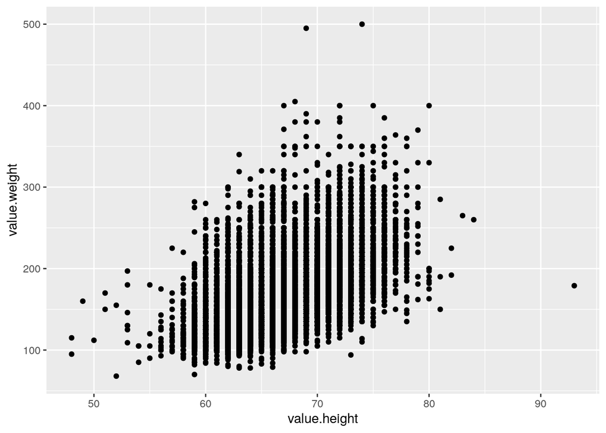

```r
ggplot(data = check, mapping = aes(x=value.height, y=value.weight)) + geom_point()
```

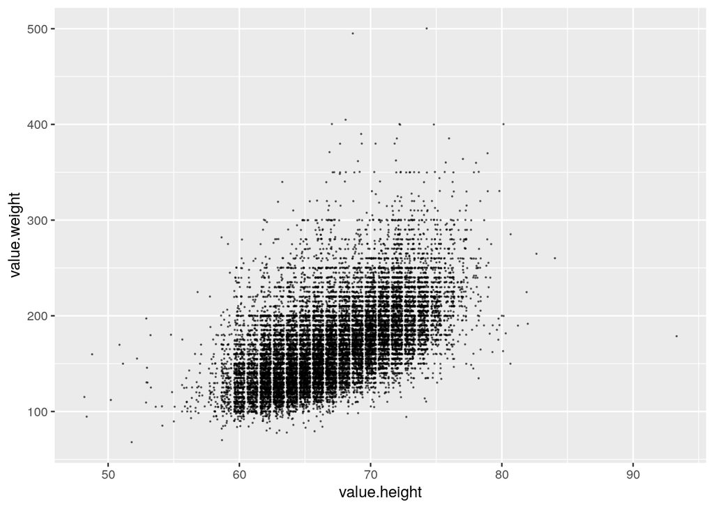

```r
Jam <- ggplot(data = check, mapping = aes(x=value.height, y=value.weight)) +geom_jitter(size=.1, alpha =.5)
Jam
```

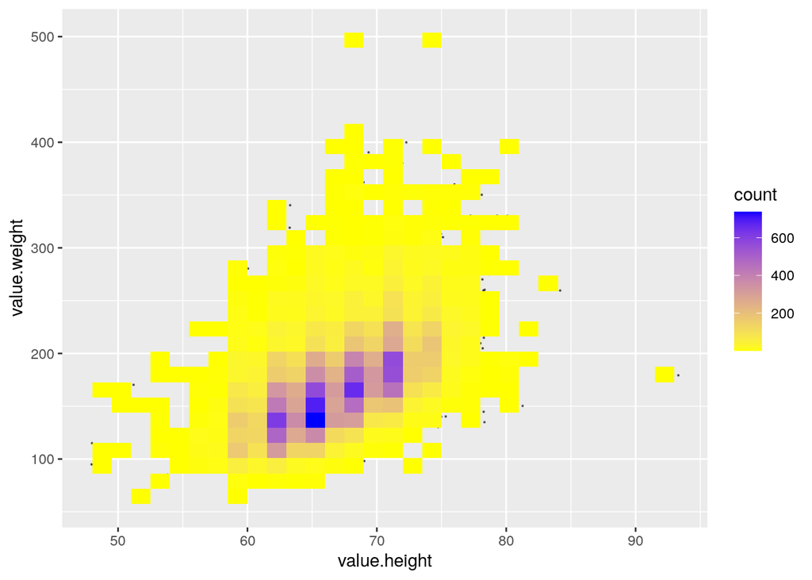

```r
Jam + geom_bin2d()+scale_fill_gradient(low = "yellow", high = "blue")
```

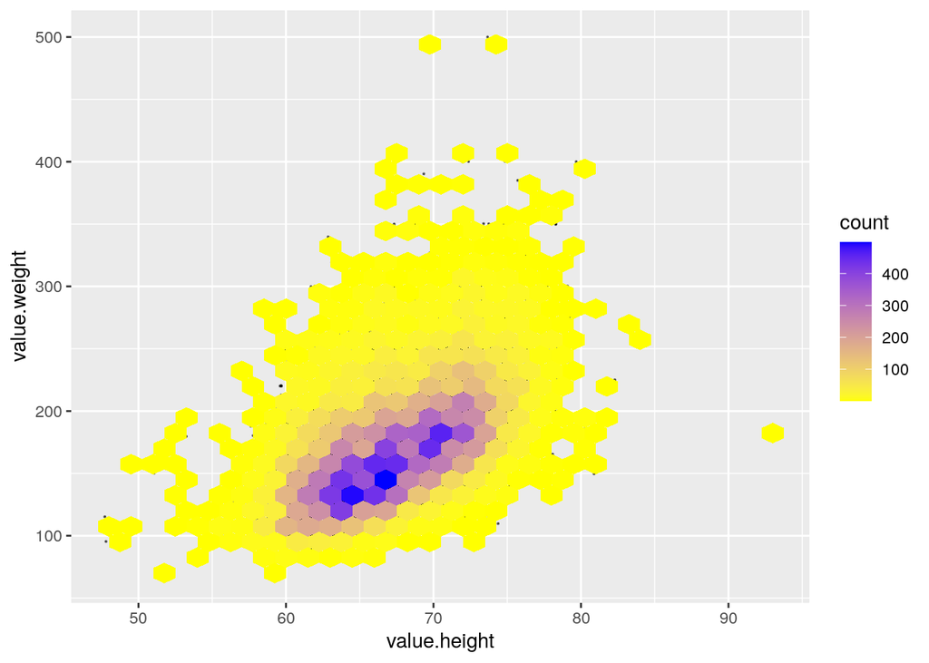

```r
Jam + geom_hex()+scale_fill_gradient(low = "yellow", high = "blue")
```

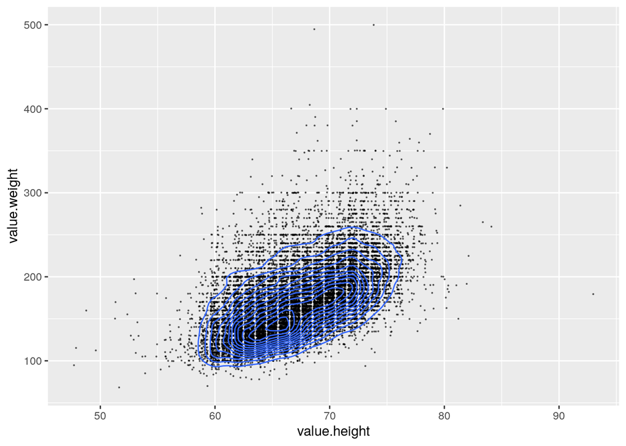

```r
Jam + geom_density2d()
```

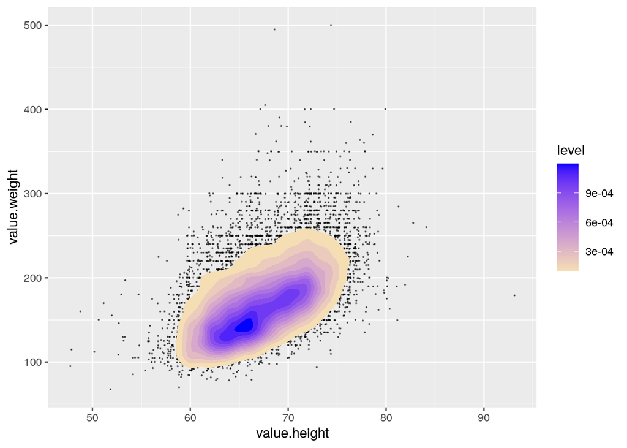

```r
Jam + stat_density2d(aes(fill = after_stat(level)), geom = "polygon") +
 scale_fill_gradient(low = "wheat", high = "blue")
```

#Question 5: (Done) a. How do the distributions of occupations of the sons in the 3 countries compare?

Uk = Highest LoM, Lowest Farm & Lowest LoNM from data. UpM is nearly on par with UpM of US. USA = Comparing UK to US data, structure is very similar. LoM are both the highest values, Farm the loqest, LoNM is the second lowest. However, notably, there are more UPNM from US than UK. Japan is the most different from the set of 3. Very middling all around. Notably, Farm is still the lowest but the highest level for Japan is LoNM.

2. How do the distributions of the sons’ and fathers’ occupations in the UK compare?

Similar UpM & LoNM rating for Both. 3 times higher Farm rating for Father than Son. LoM is largest distribution for both Son and Father. Slightly higher for Father. UpNM distribution is twice as big for Son than Father.

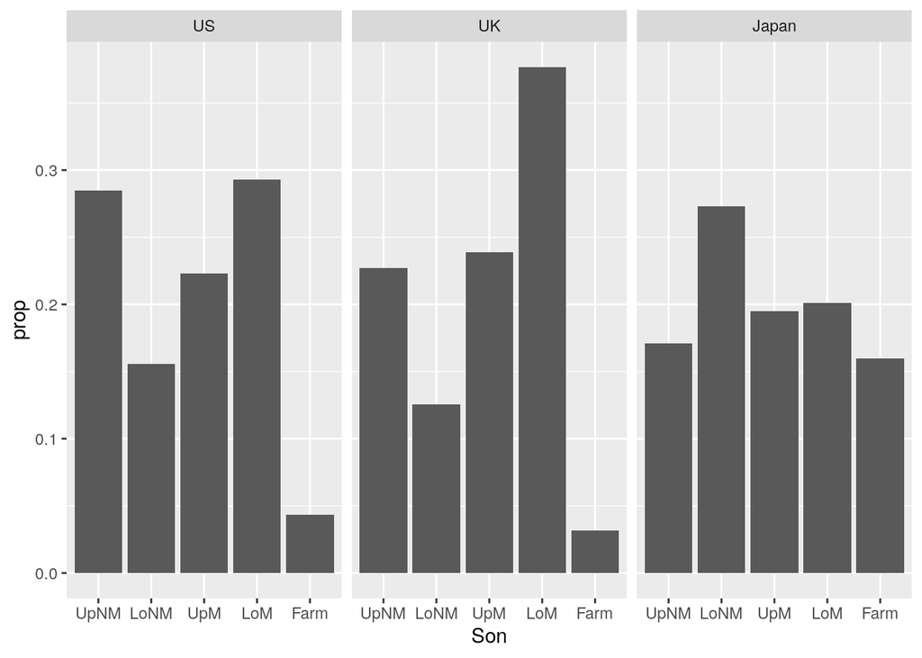

```r
Yamaguchi87 <- data.frame((Yamaguchi87))
ggplot(Yamaguchi87, aes(x=Son, weight = Freq, y = after_stat(prop), group=Country)) + geom_bar() + facet_wrap(vars(Country))
```

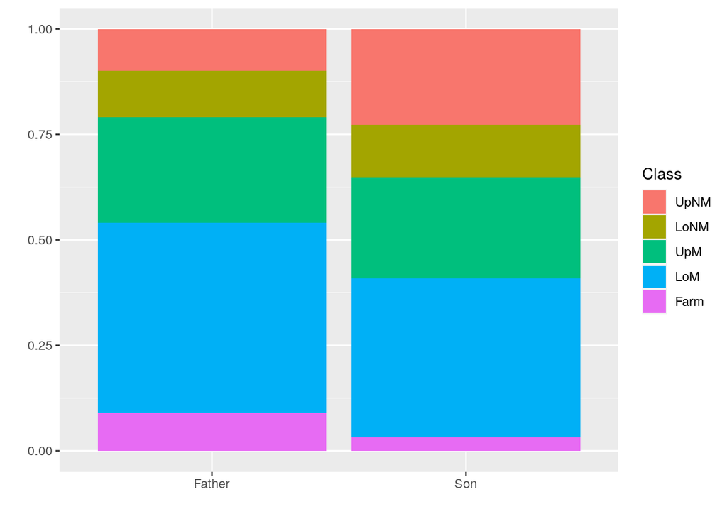

```r
filter(Yamaguchi87, Country == "UK") |>
  pivot_longer(c(Son,Father), names_to = "person", values_to = "Class") |>
  ggplot(aes(x=person, y = Freq, fill=Class)) + geom_col(position="fill") + xlab("") + ylab("")
```